# PCIT-CoS-Waitlist RCT Paper 1: DECA Total Protective Factors

Nancy Briggs

24 May 2022

### DECATotal Protective Factors

NOTE THE RESIDUALS FOR THIS OUTCOME ARE NOT GREAT AND A LOG TRANSFORM DOESNT HELP

#### Descriptives

| group | time | n | mean | sd | median | min | max |
| --- | --- | --- | --- | --- | --- | --- | --- |
| 1 | 1 | 30 | 37.06667 | 10.563220 | 33.0 | 28 | 64 |
| 1 | 2 | 24 | 36.50000 | 10.774366 | 33.0 | 28 | 63 |
| 1 | 3 | 19 | 31.57895 | 4.180853 | 28.0 | 28 | 39 |
| 2 | 1 | 27 | 37.44444 | 11.839742 | 34.0 | 28 | 64 |
| 2 | 2 | 13 | 34.84615 | 9.872910 | 33.0 | 28 | 63 |
| 2 | 3 | 5 | 31.80000 | 3.768289 | 32.0 | 28 | 36 |
| 3 | 1 | 30 | 38.73333 | 10.278647 | 36.0 | 28 | 67 |
| 3 | 2 | 26 | 31.57692 | 4.776384 | 28.5 | 28 | 43 |
| 3 | 3 | 0 | NaN | NA | NA | Inf | -Inf |

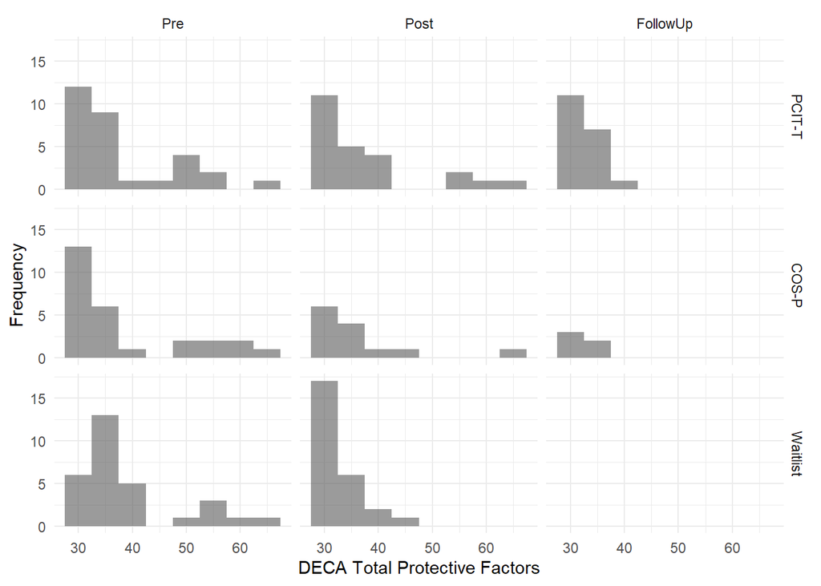

#### Model & Results

A linear mixed model with random effect for individual and fixed effects of group, time and the interaction was run. Estimated marginal means were obtained, and contrasts specified to test Hypothesis 1 and Hypothesis 2.

```
## fixed-effect model matrix is rank deficient so dropping 1 column / coefficient
```

This is the ANOVA table for the model. p-values are likelihood ratio tests for adding the new term to the model just before. A p-value <0.05 indicates that adding that term results in better model fit. The most important p-value is the interaction p-value. Here, there is no evidence that the pattern of change over time is different between the groups (p=0.258).

```
## refitting model(s) with ML (instead of REML)
```

|  | Effect | npar | AIC | BIC | logLik | deviance | Chisq | Df | Pr(>Chisq) |
| --- | --- | --- | --- | --- | --- | --- | --- | --- | --- |
| result0 | Intercept | 3 | 1281.787 | 1291.264 | -637.8937 | 1275.787 | NA | NA | NA |
| result1 | Group | 5 | 1285.675 | 1301.470 | -637.8376 | 1275.675 | 0.1121446 | 2 | 0.9454708 |
| result2 | Time | 7 | 1274.276 | 1296.389 | -630.1380 | 1260.276 | 15.3991291 | 2 | 0.0004530 |
| result3 | Group*Time | 10 | 1276.241 | 1307.831 | -628.1203 | 1256.241 | 4.0354172 | 3 | 0.2576650 |

```r
summary(result3)
```

```
## Linear mixed model fit by REML. t-tests use Satterthwaite's method [
## lmerModLmerTest]
## Formula: outcome ~ group * time + (1 | id)
##    Data: dat
##
## REML criterion at convergence: 1230.1
##
## Scaled residuals:
##     Min      1Q  Median      3Q     Max
## -1.2308 -0.6532 -0.2048  0.3851  3.0172
##
## Random effects:
##  Groups   Name        Variance Std.Dev.
##  id       (Intercept) 28.38    5.327
##  Residual             60.75    7.794
## Number of obs: 174, groups:  id, 88
##
## Fixed effects:
##              Estimate Std. Error       df t value Pr(>|t|)
## (Intercept)   37.0667     1.7237 146.4927  21.504   <2e-16 ***
## group2         0.4448     2.5021 147.5197   0.178   0.8591
## group3         1.6667     2.4376 146.4927   0.684   0.4952
## time2         -0.8904     2.1720  89.5725  -0.410   0.6828
## time3         -5.8739     2.3547  94.1681  -2.495   0.0144 *
## group2:time2  -2.3058     3.5435 105.1087  -0.651   0.5167
## group3:time2  -5.9345     3.0295  88.0436  -1.959   0.0533 .
## group2:time3  -1.1836     4.7480 111.3989  -0.249   0.8036
## ---
## Signif. codes:  0 '***' 0.001 '**' 0.01 '*' 0.05 '.' 0.1 ' ' 1
##
## Correlation of Fixed Effects:
##             (Intr) group2 group3 time2  time3  grp2:2 grp3:2
## group2      -0.689
## group3      -0.707  0.487
## time2       -0.541  0.373  0.382
## time3       -0.499  0.344  0.353  0.427
## group2:tim2  0.332 -0.490 -0.234 -0.613 -0.262
## group3:tim2  0.388 -0.267 -0.548 -0.717 -0.306  0.439
## group2:tim3  0.247 -0.361 -0.175 -0.212 -0.496  0.314  0.152
## fit warnings:
## fixed-effect model matrix is rank deficient so dropping 1 column / coefficient
```

#### Estimated Means & Change

Estimated means for each Treatment and Time are presented. In addition, within-group change between time points is presented with 95% CIs.

##### Group mean difference at each timepoint

Effect sizes all calculated by the pooled T1 SD of the outcome. Adjusted p-value from Bonferroni correction.

Group Differences at Each Time Point

| Group Difference | Time | Mean | SE | t | p | adj p | Lower CL | Upper CL | Effect Size | Lower CL | Upper CL |
| --- | --- | --- | --- | --- | --- | --- | --- | --- | --- | --- | --- |
| 1 - 2 | 1 | -0.445 | 2.503 | -0.178 | 0.983 | 1.00 | -6.369 | 5.480 | -0.040 | -0.591 | 0.508 |
| 1 - 3 | 1 | -1.667 | 2.438 | -0.684 | 0.773 | 1.00 | -7.438 | 4.104 | -0.149 | -0.720 | 0.319 |
| 2 - 3 | 1 | -1.222 | 2.503 | -0.488 | 0.877 | 1.00 | -7.146 | 4.703 | -0.109 | -0.682 | 0.389 |
| 1 - 2 | 2 | 1.861 | 3.197 | 0.582 | 0.830 | 1.00 | -5.701 | 9.423 | 0.166 | -0.492 | 0.875 |
| 1 - 3 | 2 | 4.268 | 2.654 | 1.608 | 0.245 | 0.33 | -2.012 | 10.548 | 0.382 | -0.091 | 1.037 |
| 2 - 3 | 2 | 2.407 | 3.156 | 0.763 | 0.726 | 1.00 | -5.057 | 9.871 | 0.215 | -0.427 | 0.927 |
| 1 - 2 | 3 | 0.739 | 4.531 | 0.163 | 0.985 | 1.00 | -9.981 | 11.458 | 0.066 | -0.883 | 1.051 |
| 1 - 3 | 3 | NA | NA | NA | NA | NA | NA | NA | NA | NA | NA |
| 2 - 3 | 3 | NA | NA | NA | NA | NA | NA | NA | NA | NA | NA |

* Effect size scaled by pooled T1 SD  
† ES 95% Bootstrapped Percentile CI limits  
‡ If you want a positive ES (and it is calculated as negative), be sure to switch the signs and positions of the lower and upper CIs.

##### Change within each group

Within-Group Change and Effect Sizes

| Change | Group | Mean | SE | t | p | adj p | Lower CL | Upper CL | Effect Size | Lower CL | Upper CL |
| --- | --- | --- | --- | --- | --- | --- | --- | --- | --- | --- | --- |
| 1 - 2 | 1 | 0.890 | 2.175 | 0.409 | 0.912 | 1.000 | -4.290 | 6.071 | 0.080 | -0.340 | 0.587 |
| 1 - 3 | 1 | 5.874 | 2.361 | 2.488 | 0.038 | 0.044 | 0.255 | 11.493 | 0.525 | 0.113 | 1.137 |
| 2 - 3 | 1 | 4.984 | 2.430 | 2.051 | 0.106 | 0.130 | -0.808 | 10.775 | 0.446 | 0.008 | 1.020 |
| 1 - 2 | 2 | 3.196 | 2.814 | 1.136 | 0.494 | 0.775 | -3.482 | 9.874 | 0.286 | -0.264 | 0.962 |
| 1 - 3 | 2 | 7.058 | 4.154 | 1.699 | 0.210 | 0.276 | -2.800 | 16.915 | 0.631 | -0.100 | 1.636 |
| 2 - 3 | 2 | 3.861 | 4.341 | 0.889 | 0.648 | 1.000 | -6.459 | 14.182 | 0.345 | -0.435 | 1.323 |
| 1 - 2 | 3 | 6.825 | 2.114 | 3.228 | 0.005 | 0.005 | 1.787 | 11.863 | 0.610 | 0.286 | 1.205 |
| 1 - 3 | 3 | NA | NA | NA | NA | NA | NA | NA | NA | NA | NA |
| 2 - 3 | 3 | NA | NA | NA | NA | NA | NA | NA | NA | NA | NA |

* Effect size scaled by pooled T1 SD  
† ES 95% Bootstrapped Percentile CI limits  
‡ If you want a positive ES (and it is calculated as negative), be sure to switch the signs and positions of the lower and upper CIs.

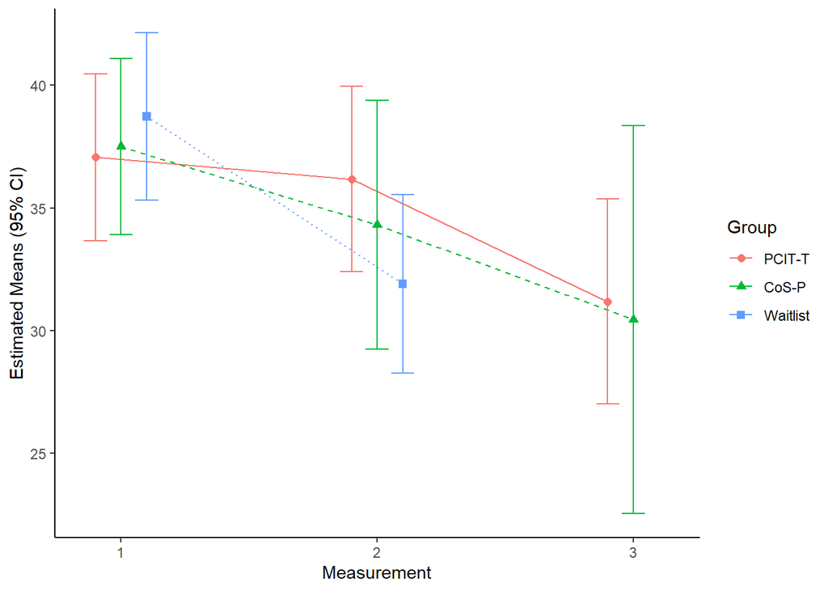

#### Hypothesis 1

We hypothesize that from baseline (‘T1’) to post-treatment/waitlist (‘T2’) there will be a gradient effect, whereby parent-child dyads who receive PCIT-T will show the greatest gains and parent-child dyads who receive no treatment will show the least gains. For the outcome, then, the null hypothesis is:

$H_0: \text {mean change}(\text{PCIT-T}) = \text {mean change}(\text{CoS-P}) = \text {mean change}(\text{Waitlist})$ $H_A: \text {mean change}(\text{PCIT-T}) > \text {mean change}(\text{CoS-P}) > \text {mean change}(\text{Waitlist})$

This is a joint hypothesis test.

First, confirming that the ordering of the means is as hypothesized:

```
## group = 1:
##  contrast estimate   SE    df t.ratio p.value
##  1 - 2        0.89 2.18  93.6   0.409  0.9119
##  1 - 3        5.87 2.36  98.2   2.488  0.0383
##  2 - 3        4.98 2.43  90.1   2.051  0.1062
##
## group = 2:
##  contrast estimate   SE    df t.ratio p.value
##  1 - 2        3.20 2.81 118.7   1.136  0.4940
##  1 - 3        7.06 4.15 120.7   1.699  0.2098
##  2 - 3        3.86 4.34 105.2   0.889  0.6481
##
## group = 3:
##  contrast estimate   SE    df t.ratio p.value
##  1 - 2        6.82 2.11  90.5   3.228  0.0049
##  1 - 3      nonEst   NA    NA      NA      NA
##  2 - 3      nonEst   NA    NA      NA      NA
##
## Degrees-of-freedom method: kenward-roger
## P value adjustment: tukey method for comparing a family of 3 estimates
```

Now, to get the p-value associated with the joint hypothesis.

```
##   (Intercept) group2 group3 time2 time3 group2:time2 group3:time2 group2:time3
## 1           0      0      0     0     0           -1            0            0
## 2           0      0      0     0     1            0            1            0
```

```
##
##   General Linear Hypotheses
##
## Linear Hypotheses:
##        Estimate
## 1 == 0    2.306
## 2 == 0  -11.808
##
## Global Test:
##      F DF1 DF2   Pr(>F)
## 1 6.75   2 164 0.001523
```

p<0.05, and the ordering of the change is as predicted (assuming a smaller decrease from T1 to T2 is desired.)

#### Hypothesis 2

There will be a gradient of size of change from T2 to T3 such that the change in the PCIT-T group > the change in the CoS-P group. This isn’t really a gradient; it’s just 1 hypothesis.

First, the change in PCITT and COSP from time 2 to time 3:

```
## group = 1:
##  contrast estimate   SE    df t.ratio p.value
##  1 - 2        0.89 2.18  93.6   0.409  0.9119
##  1 - 3        5.87 2.36  98.2   2.488  0.0383
##  2 - 3        4.98 2.43  90.1   2.051  0.1062
##
## group = 2:
##  contrast estimate   SE    df t.ratio p.value
##  1 - 2        3.20 2.81 118.7   1.136  0.4940
##  1 - 3        7.06 4.15 120.7   1.699  0.2098
##  2 - 3        3.86 4.34 105.2   0.889  0.6481
##
## group = 3:
##  contrast estimate   SE    df t.ratio p.value
##  1 - 2        6.82 2.11  90.5   3.228  0.0049
##  1 - 3      nonEst   NA    NA      NA      NA
##  2 - 3      nonEst   NA    NA      NA      NA
##
## Degrees-of-freedom method: kenward-roger
## P value adjustment: tukey method for comparing a family of 3 estimates
```

```
##
##   Simultaneous Tests for General Linear Hypotheses
##
## Fit: lmer(formula = outcome ~ group * time + (1 | id), data = dat)
##
## Linear Hypotheses:
##        Estimate Std. Error z value Pr(>|z|)
## 1 == 0    1.122      4.955   0.227    0.821
## (Adjusted p values reported -- single-step method)
```

p>0.05, so we do not have enough evidence to suggest that the change from t2 to t3 in PCITT is greater than the change in COSP.

#### Residuals

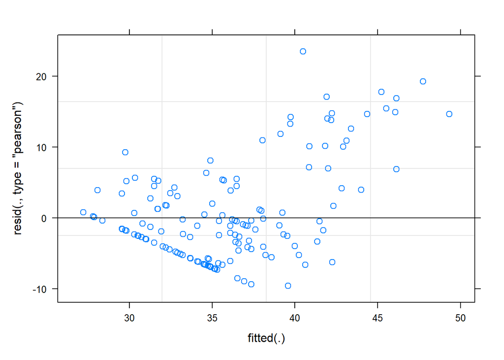

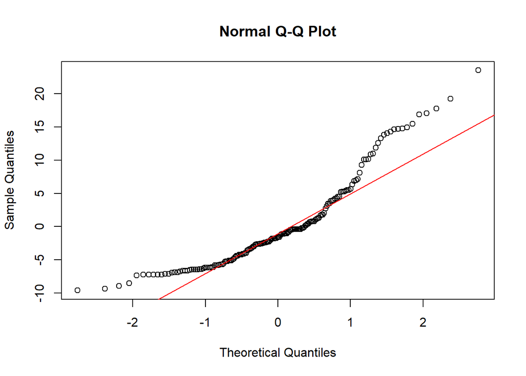

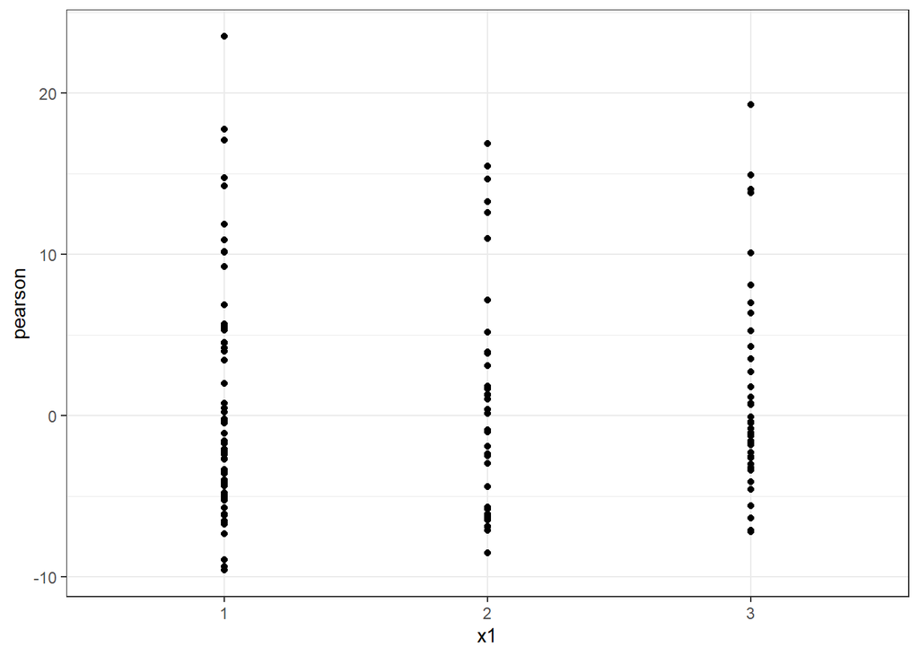

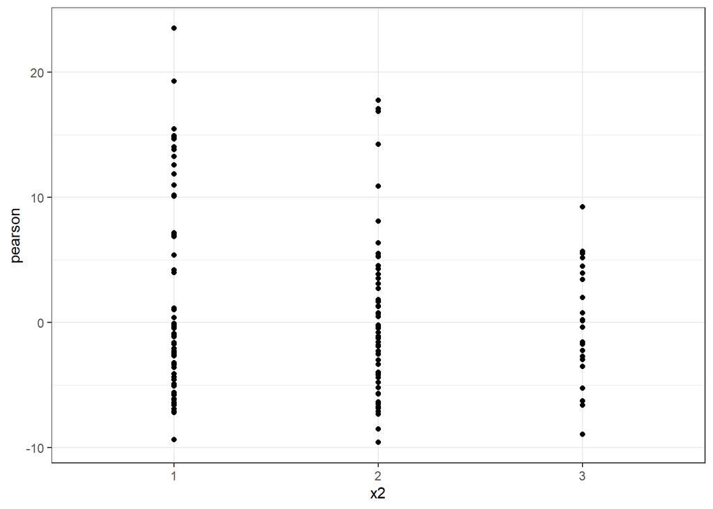

```r
rm(list = ls())
```